# Assignment 7

Look at the histogram of at least 2 columns with numerical data in the dataset that you chose in portfolio assignment 4. Do you recognise the distribution? Does it look like a uniform or normal distribution or something else? If it doesn't look like a uniform or normal distribution, take a quick look here to see if you can find the distribution shape: https://www.itl.nist.gov/div898/handbook/eda/section3/eda366.htm

```python
import pandas as pd
pokémon = pd.read_csv('pokemon.csv', sep=',')
pokémon
```

|  | # | Name | Type 1 | Type 2 | Total | HP | Attack | Defense | Sp. Atk | Sp. Def | Speed | Generation | Legendary |
| --- | --- | --- | --- | --- | --- | --- | --- | --- | --- | --- | --- | --- | --- |
| 0 | 1 | Bulbasaur | Grass | Poison | 318 | 45 | 49 | 49 | 65 | 65 | 45 | 1 | False |
| 1 | 2 | Ivysaur | Grass | Poison | 405 | 60 | 62 | 63 | 80 | 80 | 60 | 1 | False |
| 2 | 3 | Venusaur | Grass | Poison | 525 | 80 | 82 | 83 | 100 | 100 | 80 | 1 | False |
| 3 | 3 | VenusaurMega Venusaur | Grass | Poison | 625 | 80 | 100 | 123 | 122 | 120 | 80 | 1 | False |
| 4 | 4 | Charmander | Fire | NaN | 309 | 39 | 52 | 43 | 60 | 50 | 65 | 1 | False |
| ... | ... | ... | ... | ... | ... | ... | ... | ... | ... | ... | ... | ... | ... |
| 795 | 719 | Diancie | Rock | Fairy | 600 | 50 | 100 | 150 | 100 | 150 | 50 | 6 | True |
| 796 | 719 | DiancieMega Diancie | Rock | Fairy | 700 | 50 | 160 | 110 | 160 | 110 | 110 | 6 | True |
| 797 | 720 | HoopaHoopa Confined | Psychic | Ghost | 600 | 80 | 110 | 60 | 150 | 130 | 70 | 6 | True |
| 798 | 720 | HoopaHoopa Unbound | Psychic | Dark | 680 | 80 | 160 | 60 | 170 | 130 | 80 | 6 | True |
| 799 | 721 | Volcanion | Fire | Water | 600 | 80 | 110 | 120 | 130 | 90 | 70 | 6 | True |

800 rows × 13 columns

## 1. Sterkte van attacks van de pokémons

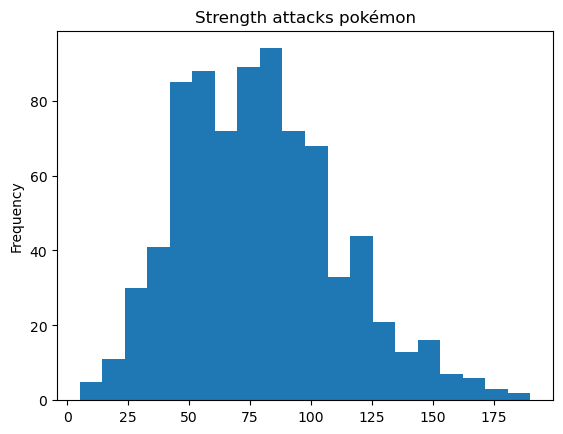

```python
pokémon['Attack'].plot(kind='hist', bins=20, title='Strength attacks pokémon')
```

### Uniform & distribution

De attacks van de pokémons zijn niet univorm verdeeld maar het lijkt wel veel op een normale distributie door hoe het aan beide zeide laag begint en het midden de hoogste waardes omvangt. Het lijkt dat de waardes aan beide kanten van het midden evenveel stijgen en dalen.

## 2. Totale kracht van de pokémons

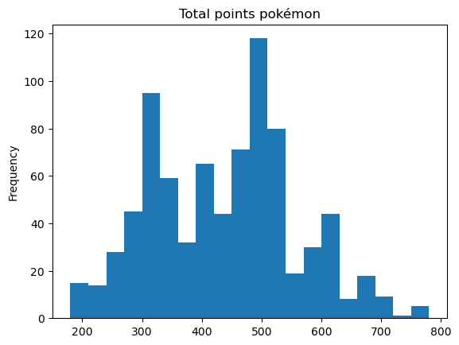

```python
pokémon['Total'].plot(kind='hist', bins=20, title='Total points pokémon')
```

### Uniform & distribution

De total van alle pokémon zijn niet uniform verdeeld of een normale distributie. Deze distributie is lastig te bepalen en het lijkt erop alsnog je twee toppen hebt en de rechter kant een stuk langer afzwakt. Daarom zou ik hier kiezen voor een Chi-Square distributie.